# Week 1 Introduction to Python Programming

## Dr Basel Barakat

### Aims of the workshop

#### Introduction to Python Programming: We'll kick things off by building a solid foundation in Python. Python is a powerful and versatile programming language widely used in AI development due to its readability and extensive libraries.

### Feel free to discuss your work with peers, or with any member of the teaching staff.

##### Python is a general-purpose interpreted, interactive, object-oriented, and high-level programming language. It was created by Guido van Rossum during 1985- 1990.

##### Python 3 is available for Windows, Mac OS and most of the flavours of Linux operating system.

##### Python is Interpreted − Python is processed at runtime by the interpreter. You do not need to compile your program before executing it.

##### Python is Interactive − You can actually sit at a Python prompt and interact with the interpreter directly to write your programs.

##### Python is Object-Oriented − Python supports Object-Oriented style or technique of programming that encapsulates code within objects.

##### Python is a Beginner's Language − Python is a great language for the beginner-level programmers and supports the development of a wide range of applications from simple text processing to WWW browsers to games.

### Printing simple sentence

```python
print("Welcome from  Goldsmith")
```

```
Welcome from  Goldsmith
```

#### Q: Write a script to print your name

```python
# please solve it bellow

print('Basel')
```

```
Basel
```

### We can use Python as a simple calculator

```python
print(5 + 2)
```

```
7
```

```python
print(5 - 3 )
```

```
2
```

#### lets try something more complicated

```python
print(98142317984791834618792381983476 + 34812345678725456789749023884169482)
```

```
34910487996710248624367816266152958
```

#### Q: Try two massive numbers

```python
#please solve it bellow
print(19999999922 + 9111111111111111222)
```

#### Some multiplications ... why not

```python
print(2 * 5)
```

```
10
```

```python
print( 10 * 9)
```

```
90
```

```python
print(9876578908765465768798 * 563418763018)
```

```
5564649871626307000932791540712364
```

```python
print( 6 / 3)
```

```
2.0
```

```python
print( 24 / 2)
```

```
12.0
```

### Defining variables

```python
x = 10

print(x)
```

```
10
```

```python
x = 20
y = 5

print( x * y)
```

```
100
```

#### Define 2 variables, one for cost before VAT (e.g. £100) and one after (assuming that VAT is 25%).

```python
# please solve it bellow

cost=100
vat=1.25

print(cost*vat)
```

```
125.0
```

```python
print(x / y)
```

```
4.0
```

### Define string variable

```python
name = 'Basel'

print(name)
```

```
Basel
```

```python
First_name = 'Basel'
Sure_name = ' Barakat'

print(First_name)
print(Sure_name)
print(First_name + Sure_name)
```

```
Basel
 Barakat
Basel Barakat
```

#### we can also do some changes to the saved strings

```python
print(First_name)

print(First_name.lower())

print(First_name.upper())
```

```
Basel
basel
BASEL
```

### Taking user input

```python
user_name = input(' Please type your first name:  ')

print('Hello ', user_name)
```

```
Hello  Basel
```

#### Q: write a script to ask for a number, then multiple it by 2 and print the result

```python
# please solve here

number = input('Please type a number:  ')
number = int(number)
print(number * 2)
```

```
6
```

### Data Collections

#### So what if we want to save multiple value? So for example if we want to save the names of every one attending this training, but we do not know how many will come beforehand

#### We can use data arrays

```python
my_list = [5,10,15]

print(my_list)
```

```
[5, 10, 15]
```

#### To add a value to the list we can use append()

```python
my_list.append(20)

print(my_list)
```

```
[5, 10, 15, 20]
```

#### Q: write script that would take the user input and add it to the end of the list

```python
# please solve here
my_list = [5,10,15]
number = input('Please type a number:  ')
number = int(number)
my_list.append(number)
print(my_list)
```

```
[5, 10, 15, 30]
```

#### To find the last value of the list we can call it by its location as follows:

```python
print(my_list[3])

#please note the python start counting from 0
```

[output not shown]

#### or we can use -1

```python
print(my_list[-1])
```

[output not shown]

#### To know the size of the list we can use the len() command

```python
print(len(my_list))
```

```
4
```

### Conditions

#### In some cases we would like to check if a variable satisfy a conditions. For example if the mark is greater than 5 then would show Pass

```python
mark = 6

if mark > 5:
    print('pass')
```

```
pass
```

#### Q: write a script to print fail if the mark is lower than 5

```python
# Please solve it here
mark = 4
if mark > 5:
    print('pass')
else:
    print('fail')
```

```
fail
```

#### Q: write a script to entre a mark from the user and check if it is a pass or fail

```python
# Please solve it here
mark = input('Please type your mark:  ')
mark = int(mark)
if mark > 5:
    print('pass')
else:
    print('fail')
```

```
fail
```

### Loops

#### If we need to redo a part of the code multiple times we can use loops. One of the most useful loop methods is For which can be used as follows:

```python
msg = ' Hello '
for i in range (3):
    print(msg)
```

```
 Hello
 Hello
 Hello
```

#### We can also use it with lists as follows:

```python
new_list = [1,2,3,4,5]

for value in new_list:
    print(value)
```

```
1
2
3
4
5
```

#### Q: crate a list with 5 values

```python
# please solve here
my_list = [1,2,3,4,5]
```

#### Q: write a script to loop through the created list and check if the value is greater than 10 print more than 10

```python
# please solve here
my_list = [1, 2, 3, 4, 5]

for value in my_list:
    if value > 10:
        print(f"{value} is more than 10")
    else:
        print(f"{value} is less than 10")
```

[output not shown]

### Functions

#### If we want to use a part of the code many time we can deine our own function

```python
def checker(value):

    if value > 10:
        print(value ,' is greater than 10 ')


checker(100)
```

```
100  is greater than 10
```

```python
new_list = [100, 0, 50, 60]

for value in new_list:
    checker(value)
```

```
100  is greater than 10
50  is greater than 10
60  is greater than 10
```

### Introduction to Pandas

#### Pandas is a Python package that provides fast, flexible, and expressive data structures designed to make working with "relational" or "labeled" data both easy and intuitive. It aims to be the fundamental high-level building block for doing practical, real world data analysis in Python. Additionally, it has the broader goal of becoming the most powerful and flexible open-source data analysis / manipulation tool available in any language. It is already well on its way towards this goal.

#### To use Pandas we need to install and import it first

```python
pip install pandas
```

```python
import pandas as pd
```

#### let use use it to open a spreadsheet. In this example we have the grades of 395 students in 3 exams G1,G2 and G3

```python
file_name = 'student-mat.csv'


df = pd.read_csv(file_name, sep=';')

display(df)
```

|  | school | sex | age | address | famsize | Pstatus | Medu | Fedu | Mjob | Fjob | ... | famrel | freetime | goout | Dalc | Walc | health | absences | G1 | G2 | G3 |
| --- | --- | --- | --- | --- | --- | --- | --- | --- | --- | --- | --- | --- | --- | --- | --- | --- | --- | --- | --- | --- | --- |
| 0 | GP | F | 18 | U | GT3 | A | 4 | 4 | at_home | teacher | ... | 4 | 3 | 4 | 1 | 1 | 3 | 6 | 5 | 6 | 6 |
| 1 | GP | F | 17 | U | GT3 | T | 1 | 1 | at_home | other | ... | 5 | 3 | 3 | 1 | 1 | 3 | 4 | 5 | 5 | 6 |
| 2 | GP | F | 15 | U | LE3 | T | 1 | 1 | at_home | other | ... | 4 | 3 | 2 | 2 | 3 | 3 | 10 | 7 | 8 | 10 |
| 3 | GP | F | 15 | U | GT3 | T | 4 | 2 | health | services | ... | 3 | 2 | 2 | 1 | 1 | 5 | 2 | 15 | 14 | 15 |
| 4 | GP | F | 16 | U | GT3 | T | 3 | 3 | other | other | ... | 4 | 3 | 2 | 1 | 2 | 5 | 4 | 6 | 10 | 10 |
| ... | ... | ... | ... | ... | ... | ... | ... | ... | ... | ... | ... | ... | ... | ... | ... | ... | ... | ... | ... | ... | ... |
| 390 | MS | M | 20 | U | LE3 | A | 2 | 2 | services | services | ... | 5 | 5 | 4 | 4 | 5 | 4 | 11 | 9 | 9 | 9 |
| 391 | MS | M | 17 | U | LE3 | T | 3 | 1 | services | services | ... | 2 | 4 | 5 | 3 | 4 | 2 | 3 | 14 | 16 | 16 |
| 392 | MS | M | 21 | R | GT3 | T | 1 | 1 | other | other | ... | 5 | 5 | 3 | 3 | 3 | 3 | 3 | 10 | 8 | 7 |
| 393 | MS | M | 18 | R | LE3 | T | 3 | 2 | services | other | ... | 4 | 4 | 1 | 3 | 4 | 5 | 0 | 11 | 12 | 10 |
| 394 | MS | M | 19 | U | LE3 | T | 1 | 1 | other | at_home | ... | 3 | 2 | 3 | 3 | 3 | 5 | 5 | 8 | 9 | 9 |

395 rows × 33 columns

To display the first 5 rows only we can use .head() as follows:

```python
display(df.head())
```

|  | school | sex | age | address | famsize | Pstatus | Medu | Fedu | Mjob | Fjob | ... | famrel | freetime | goout | Dalc | Walc | health | absences | G1 | G2 | G3 |
| --- | --- | --- | --- | --- | --- | --- | --- | --- | --- | --- | --- | --- | --- | --- | --- | --- | --- | --- | --- | --- | --- |
| 0 | GP | F | 18 | U | GT3 | A | 4 | 4 | at_home | teacher | ... | 4 | 3 | 4 | 1 | 1 | 3 | 6 | 5 | 6 | 6 |
| 1 | GP | F | 17 | U | GT3 | T | 1 | 1 | at_home | other | ... | 5 | 3 | 3 | 1 | 1 | 3 | 4 | 5 | 5 | 6 |
| 2 | GP | F | 15 | U | LE3 | T | 1 | 1 | at_home | other | ... | 4 | 3 | 2 | 2 | 3 | 3 | 10 | 7 | 8 | 10 |
| 3 | GP | F | 15 | U | GT3 | T | 4 | 2 | health | services | ... | 3 | 2 | 2 | 1 | 1 | 5 | 2 | 15 | 14 | 15 |
| 4 | GP | F | 16 | U | GT3 | T | 3 | 3 | other | other | ... | 4 | 3 | 2 | 1 | 2 | 5 | 4 | 6 | 10 | 10 |

5 rows × 33 columns

Now we can start analysing the data to get good understating of it.

```python
# Display basic information about the dataset
print("Shape of the DataFrame:")
print(df.shape)
```

```
Shape of the DataFrame:
(395, 33)
```

```python
print("\nColumns in the DataFrame:")
print(df.columns)
```

```
Columns in the DataFrame:
Index(['school', 'sex', 'age', 'address', 'famsize', 'Pstatus', 'Medu', 'Fedu',
       'Mjob', 'Fjob', 'reason', 'guardian', 'traveltime', 'studytime',
       'failures', 'schoolsup', 'famsup', 'paid', 'activities', 'nursery',
       'higher', 'internet', 'romantic', 'famrel', 'freetime', 'goout', 'Dalc',
       'Walc', 'health', 'absences', 'G1', 'G2', 'G3'],
      dtype='object')
```

To get a statistical analysis of the data we can use pandas describe tool, as follows:

```python
# Display summary statistics of numerical columns
print("\nSummary Statistics:")
display(df.describe())
```

```
Summary Statistics:
```

|  | age | Medu | Fedu | traveltime | studytime | failures | famrel | freetime | goout | Dalc | Walc | health | absences | G1 | G2 | G3 |
| --- | --- | --- | --- | --- | --- | --- | --- | --- | --- | --- | --- | --- | --- | --- | --- | --- |
| count | 395.000000 | 395.000000 | 395.000000 | 395.000000 | 395.000000 | 395.000000 | 395.000000 | 395.000000 | 395.000000 | 395.000000 | 395.000000 | 395.000000 | 395.000000 | 395.000000 | 395.000000 | 395.000000 |
| mean | 16.696203 | 2.749367 | 2.521519 | 1.448101 | 2.035443 | 0.334177 | 3.944304 | 3.235443 | 3.108861 | 1.481013 | 2.291139 | 3.554430 | 5.708861 | 10.908861 | 10.713924 | 10.415190 |
| std | 1.276043 | 1.094735 | 1.088201 | 0.697505 | 0.839240 | 0.743651 | 0.896659 | 0.998862 | 1.113278 | 0.890741 | 1.287897 | 1.390303 | 8.003096 | 3.319195 | 3.761505 | 4.581443 |
| min | 15.000000 | 0.000000 | 0.000000 | 1.000000 | 1.000000 | 0.000000 | 1.000000 | 1.000000 | 1.000000 | 1.000000 | 1.000000 | 1.000000 | 0.000000 | 3.000000 | 0.000000 | 0.000000 |
| 25% | 16.000000 | 2.000000 | 2.000000 | 1.000000 | 1.000000 | 0.000000 | 4.000000 | 3.000000 | 2.000000 | 1.000000 | 1.000000 | 3.000000 | 0.000000 | 8.000000 | 9.000000 | 8.000000 |
| 50% | 17.000000 | 3.000000 | 2.000000 | 1.000000 | 2.000000 | 0.000000 | 4.000000 | 3.000000 | 3.000000 | 1.000000 | 2.000000 | 4.000000 | 4.000000 | 11.000000 | 11.000000 | 11.000000 |
| 75% | 18.000000 | 4.000000 | 3.000000 | 2.000000 | 2.000000 | 0.000000 | 5.000000 | 4.000000 | 4.000000 | 2.000000 | 3.000000 | 5.000000 | 8.000000 | 13.000000 | 13.000000 | 14.000000 |
| max | 22.000000 | 4.000000 | 4.000000 | 4.000000 | 4.000000 | 3.000000 | 5.000000 | 5.000000 | 5.000000 | 5.000000 | 5.000000 | 5.000000 | 75.000000 | 19.000000 | 19.000000 | 20.000000 |

To check for any missing data, we can use:

```python
# Check for any missing values
print("\nMissing Values:")
print(df.isnull().sum())
```

```
Missing Values:
school        0
sex           0
age           0
address       0
famsize       0
Pstatus       0
Medu          0
Fedu          0
Mjob          0
Fjob          0
reason        0
guardian      0
traveltime    0
studytime     0
failures      0
schoolsup     0
famsup        0
paid          0
activities    0
nursery       0
higher        0
internet      0
romantic      0
famrel        0
freetime      0
goout         0
Dalc          0
Walc          0
health        0
absences      0
G1            0
G2            0
G3            0
dtype: int64
```

To check for duplicated row, we can use:

```python
# Check for any duplicate rows
print("\nDuplicate Rows:")
print(df.duplicated().sum())
```

```
Duplicate Rows:
0
```

To visualize the grades of the first 10 students we can use the following:

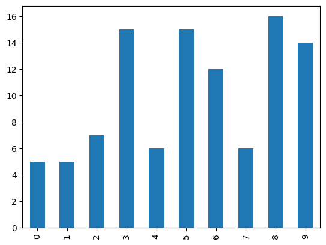

```python
df['G1'][:10].plot(kind='bar')
```

We can do more complicated analysis and visualisation such as a heat map of correlations between different parameters

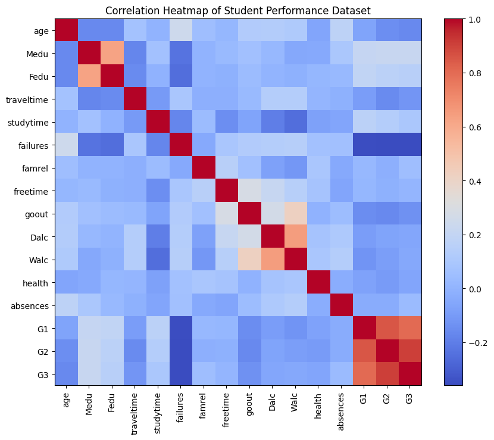

```python
import matplotlib.pyplot as plt

# Selecting only numerical columns
numerical_columns = df.select_dtypes(include=['int64', 'float64'])

# Calculating correlations
correlations = numerical_columns.corr()

# Creating a basic heatmap to visualise the correlations
plt.figure(figsize=(10, 8))
plt.imshow(correlations, cmap='coolwarm', interpolation='nearest')
plt.colorbar()
plt.xticks(range(len(correlations)), correlations.columns, rotation=90)
plt.yticks(range(len(correlations)), correlations.columns)
plt.title('Correlation Heatmap of Student Performance Dataset')
plt.show()
```